# **FACTORES QUE INFLUYERON EN EL RENDIMIENTO ACADÉMICO DE LOS ESTUDIANTES DE LA UTEC EN EL PERÍODO 2022-2**

## **Identificar cuál de los dos géneros es más propenso a ser afectado en su rendimiento académico.**

- Primero hallamos el promedio de las notas de los cursos

```r
EL$Notas_promedio=round(((EL$Letras+EL$Matemáticas+EL$Ciencias)/3),2)
```

```r
summary(EL$Notas_promedio)
```

```
##    Min. 1st Qu.  Median    Mean 3rd Qu.    Max.
##   10.53   14.20   15.33   15.21   16.33   19.33
```

- Calculamos el promedio de notas por cada género

```r
promedios <- EL %>%
  group_by(Género) %>%
  summarise(Notas_promedio = round(mean(Notas_promedio),2))

# Imprimir la tabla de promedios
print(promedios)
```

```
## # A tibble: 2 x 2
##   Género    Notas_promedio
##   <chr>              <dbl>
## 1 Femenino            15.3
## 2 Masculino           15.2
```

- Se realiza una tabla de la variable Género, para identificar la cantidad de encuestados por género

```r
table(EL$Género)
```

```
##
##  Femenino Masculino
##        86       118
```

- La cantidad de encuestados, pero en porcentajes

```r
# Calcular las frecuencias
frecuencias <- table(EL$Género)

# Calcular el porcentaje
porcentaje <- frecuencias / sum(frecuencias) * 100

# Crear una nueva columna con el porcentaje en formato de texto
resultado <- data.frame(Género = names(frecuencias),
                        Porcentaje = paste0(round(porcentaje), "%"))

# Imprimir los resultados
print(resultado)
```

```
##      Género Porcentaje
## 1  Femenino        42%
## 2 Masculino        58%
```

- Realizamos una tabla en el cual nos permitirá ver mejor la cantidad de encuestados por género

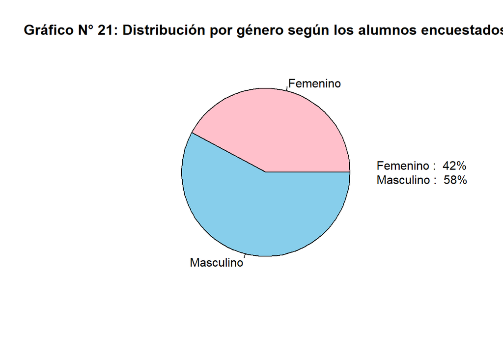

```r
# Calcular la cantidad por género utilizando dplyr
conteo_genero <- EL %>%
  group_by(Género) %>%
  summarise(cantidad = n())

# Crear el gráfico de pastel
pie(conteo_genero$cantidad, labels = paste(conteo_genero$Género),
    main = "Gráfico N° 21: Distribución por género según los alumnos encuestados",
    col = c( "pink" , "skyblue" ))

# Agregar leyenda
legend("right", legend = paste(conteo_genero$Género, ": ", resultado$Porcentaje), cex = 0.99, bty = "n")
```

**Análisis:** **Según este gráfico, podemos identificar que más de la mitad de encuestados es del género masculino a diferencia del género femenino.**

- En este gráfico promedio de notas por genero para ver

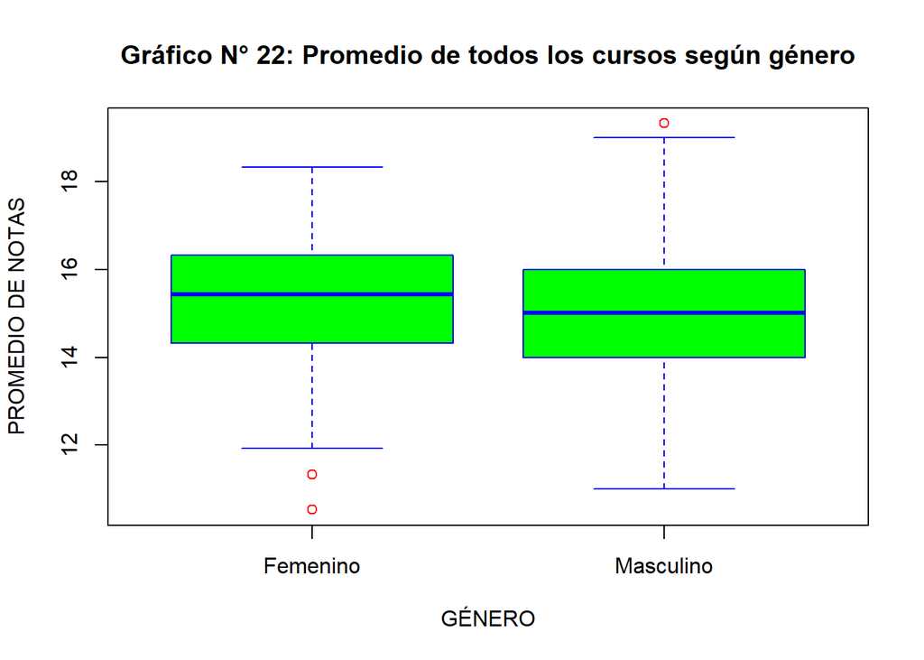

```r
boxplot(EL$Notas_promedio~EL$Género, col="green", xlab = "GÉNERO", ylab = "PROMEDIO DE NOTAS", main = "Gráfico N° 22: Promedio de todos los cursos según género", outcol = "red", border = "blue")
```

- Calcular los cuartiles por género

```r
cuartiles_por_genero <- aggregate(Notas_promedio ~ Género, data = EL, FUN = quantile, probs = c(0.25, 0.5, 0.75))

# Imprimir los resultados
print(cuartiles_por_genero)
```

```
##      Género Notas_promedio.25% Notas_promedio.50% Notas_promedio.75%
## 1  Femenino              14.33              15.44              16.33
## 2 Masculino              14.00              15.02              16.00
```

**Análisis** **Con este Boxplop, vemos que no hay mucha diferencia en los promedios entre ambos géneros. Pero también, observamos que estas diferencias pueden depender de las diferencias de cuartiles (Q3-Q1) y no es mucha la diferencia, eso indica que no hay una dispersión o variabilidad significativa en los datos entre esos puntos. Esto puede sugerir que la distribución de los valores es relativamente homogénea o que la dispersión es pequeña**

## VI BIBLIOGRAFÍA

- Hattie, J. (2009). Visible learning: A synthesis of over 800 meta-analyses relating to achievement. Routledge.
- Cruz Zuluaga, M. N. (2016, junio). Factores que influyen en el rendimiento académico del estudiante. http://repositorio.esumer.edu.co/jspui/handle/esumer/363

$$GRACIAS 🌹$$